# Chapter D3 構造設計におけるいくつかの重要詳細

### (b) 局所的な方向変化を持つフランジ（折れ曲がりフランジ）（Flanges With Local Changes in Direction (Bent Flanges)）

これは上記の (a) の特殊なケースである。全体的な曲率の代わりに、フランジは Fig. D3.31 に示すように局所的な方向変化を持っている。

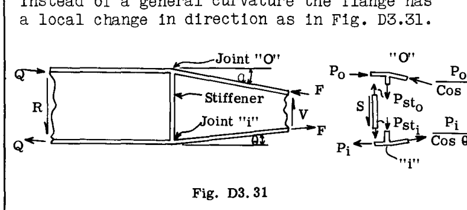

Fig. D3.31

フランジの突出した脚は、補強材がそれらを抑えるために必要な荷重を提供しない限り、上方へ移動しようとする。これはジョイントにおける静力学から計算することができる。補強材内の荷重は、その後ウェブへとせん断伝達される。補強材が設けられない場合、キック荷重がウェブを圧縮状態にし、ウェブが薄い場合には座屈が生じるため、ある程度の強度は存在するものの不十分となる。梁がバー材から機械加工される場合、補強材を所定の位置に一体加工することができる。梁が分離したフランジとウェブ部品から構成される「組立て」梁である場合、補強材は、フランジに取り付けられたT字部材と、ウェブおよびT字部材に取り付けられたアングル部材から構成することができる。これを Fig. D3.32 に示す。キック荷重の伝達経路は、フランジからT字部材へ、そこからアングル部材へ、そしてウェブへと至る。

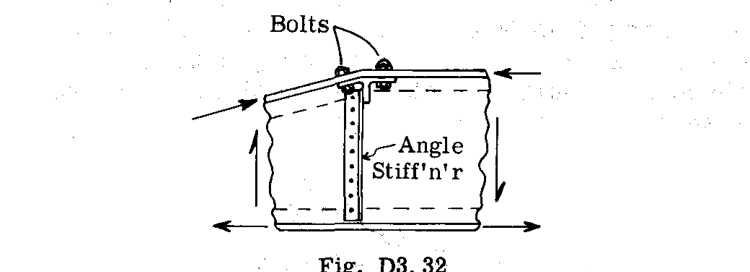

Fig. D3.32

図示された荷重はボルトに上向きの荷重を生じさせ、T字部材の脚と補強材アングルに引張力を生じさせる。逆方向の荷重はT字部材を押し下げ、圧縮を生じさせる。上記のT字部材とアングルの組み合わせは、当然ながら、単一の機械加工されたフィッティングに置き換えることができる。重要なことは、突出した脚が効果的に機能するためには、突出した脚に取り付けられた適切な補強材が存在しなければならないということである。

### (c) フランジを曲げようとする法線荷重を受けるフランジ（Flanges Subjected to Normal Loads Tending to Bend Them）

梁のフランジは、外側へ引っ張る、または内側へ押す荷重を受けることが頻繁にある。それぞれの場合において、フランジが補強材によって「裏打ち（バックアップ）」されていることが重要である。この効果は、折れ曲がりフランジによるキック荷重を伴う、いま議論したケース (b) と同様である。同様の補強材配置を使用することができる。

### (d) 面外座屈に対する安定化を必要とするフランジ（Flanges Requiring Stabilization Against Out-of-Plane Buckling）

Chapters C10 および C11 で議論されたフランジ設計のケースでは、圧縮状態にあるフランジは安定している、または何らかの支持部材によって柱としての座屈が防止されていると仮定されていた。この支持部材は、通常、フランジが取り付けられている床や外板として示されていた。したがって、フランジは梁ウェブによって一方向の平面内で拘束され、これに垂直な平面内では何らかの外板によって拘束されているため、座屈することはなかった。

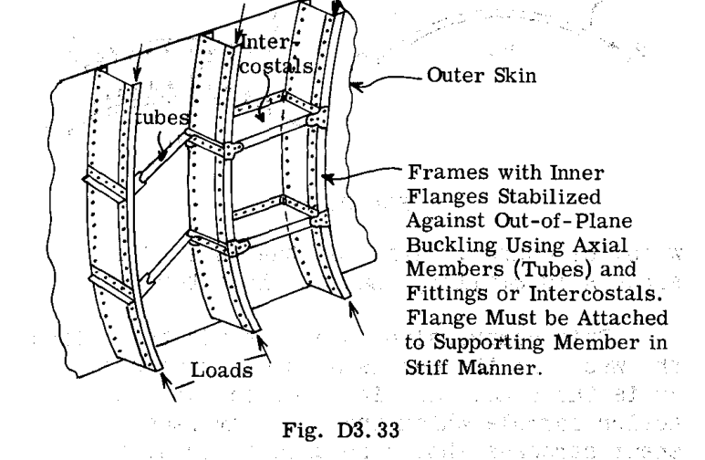

Fig. D3.33

支持部材は目立った荷重を受けないが、柱の座屈を防ぐのに十分な剛性を持たなければならない。必要な剛性基準についてはここでは議論しないが、読者は文献 (1) または同様の教科書を参照してそのような基準を得るべきである。支持部材は強度要件ではなく剛性によってサイズが決定されるため、通常は軽量なチューブや中間材（インターコスタル）で構成することができる。それらの重量は、通常、面外強度のためにバルクヘッドフランジ自体を強化することによって生じる重量よりも軽くなる。支持部材の剛性には、当然ながら、それをフランジに取り付ける端部フィッティングの剛性も含めなければならない。

## D3.8 構造外板パネルの詳細（Structural Skin Panel Details）

構造外板または床パネルの設計に関する一般的な原理は、Chapters C10 および C11 でカバーされている。特に、座屈パネルに関する Chapter C11 は、設計者によって徹底的に理解されるべきである。この情報に加えて、設計のいくつかの詳細が以下に示されている。

1. 長方形の穴
2. 凹み（リセス）付きパネル
3. パネル上への長い軸方向部材の取り付け
4. 板金ダブラーのスポット溶接
5. 引張外板のスプライス